# Taylor Series for approximating ODEs

Fonzzy

25/4/21

## Taylor Series

A taylor series is an infinite series that estimates any continuous function as a polynomial. Taylor Series defined at point x=a as :

$$\sum_{n = 0}^{\infty} = \frac{\mathbb F^{n}(a)}{n!}\cdot(x - a)^n$$

luckily, this sytem can be further defined to:

$$\sum_{n = 0}^{\infty} = \frac{ C(n)}{n!}\cdot(x - a)^n$$

with C(n) being defined as the function tht gives the value of $\mathbb F^{n}(a)$ for each n. this definition is beneficial as computationally, it is difficult to define the derivative function, unlike a simple numeric funtion.

For example, looking at the Taylor series of $e^x$ at the point a = 0

$$f(x) = e^x$$
$$f'(x) = e^x$$

And in general:
$$f^n{(x)} = e^x \quad \forall \quad n$$

For the point x = 0:

$$f^n{(0)} = 1$$
$$C(n) = 1$$

Now coding this system:

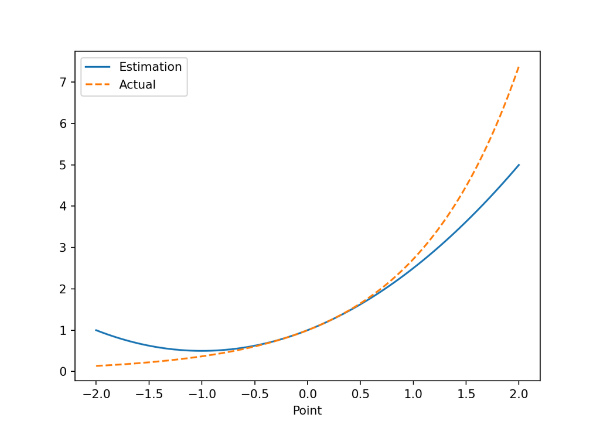

```python
import  math
import numpy as np
import  pandas as pd
import matplotlib.pyplot as plt


## Varibles to set to define simultaion
def f(x):           ## Only for plotting against estimation
    return np.exp(x)
def c(n):           ## C vaules
    return 1
a = 0               ## Around what point is this estimation
step = 0.001        ## step Size for points
width = 2           ## Range of Estimation
depth  = 3       ## Max size of n


## Create List of points
width_mult  = 1/step
new_witdh = int(round(width*width_mult))
ls_points = range(-new_witdh, new_witdh)
ls_points = list(map(lambda x: x*step, ls_points))

## Create List n
ls_n = list(range(0,depth))

## Create List of coefficients
ls_c = list(map(lambda x: c(x), ls_n))

def point_term (x, a , c , n):
    point = c / math.factorial(n) * (x-a) ** n
    return point

df = pd.DataFrame(ls_points, columns=['Point'])

## Create A datframe with each collumn being the vaules for a single n
for n in ls_n:
    df[n] = df['Point'].apply(lambda x: point_term(x,a,ls_c[n],n))

df.set_index('Point', inplace= True)

## Sum all the estimations
df_estimation = df.sum(axis = 1)

df_estimation.plot(label='Estimation')

if f(a):
    plt.plot(ls_points, list(map(lambda x: f(x), ls_points)),label='Actual', linestyle='dashed',)
plt.legend()
```

Trying this again for a polynomial 7x^2 +x +2$:

$$f'(x) = 14x + 1$$
$$f''(x) = 14$$
$$f^n(x) = 0 \quad \forall \quad n > 2$$
Unlike the exponent, c(n) has no clear pattern as a function of only n, but if statements can be implemented to give the same behaviour. looking at the point x = 2

```python
def f(x):
    return 7*x**2 + x + 2
def c(n):
    if n == 0:
        return  32
    elif n == 1:
        return 29
    elif n == 2:
        return 14
    else:
        return 0

a = 2
step = 0.1
width = 5
depth  = 3
```

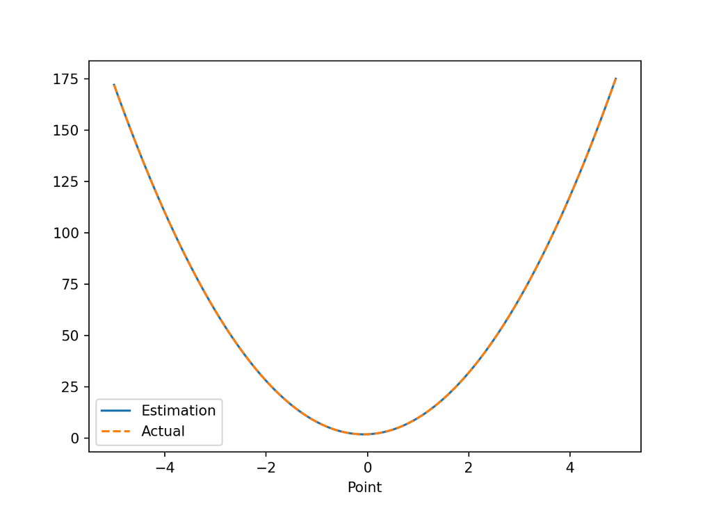

Since the derivative terms become 0, the estimation is perfect after only a few terms, and if you do the maths, you will see the polynomials are the same.